DS 6030 | Fall 2024 | University of Virginia

# Homework #6: SVM and Calibration

Author

Kiana Dane

Published

October 18, 2024

# Required R packages and Directories

```r
dir_data= 'https://mdporter.github.io/teaching/data/' # data directory
library(tidyverse)  # functions for data manipulation
library(pROC)
library(ggplot2)
library(dplyr)
```

# COMPAS Recidivism Prediction

A recidivism risk model called COMPAS was the topic of a [ProPublica article](https://www.propublica.org/article/machine-bias-risk-assessments-in-criminal-sentencing/) on ML bias. Because the data and notebooks used for article was released on [github](https://github.com/propublica/compas-analysis), we can also evaluate the prediction bias (i.e., calibration).

This code will read in the *violent crime* risk score and apply the filtering used in the [analysis](https://github.com/propublica/compas-analysis/blob/master/Compas%20Analysis.ipynb).

```r
library(tidyverse)
df = read_csv("https://raw.githubusercontent.com/propublica/compas-analysis/master/compas-scores-two-years-violent.csv")

risk = df %>%
  filter(days_b_screening_arrest <= 30) %>%
  filter(days_b_screening_arrest >= -30) %>%
  filter(is_recid != -1) %>%
  filter(c_charge_degree != "O") %>%
  filter(v_score_text != 'N/A') %>%
  transmute(
    age, age_cat,
    charge = ifelse(c_charge_degree == "F", "Felony", "Misdemeanor"),
    race,
    sex,
    priors_count = priors_count...15,
    score = v_decile_score,              # the risk score {1,2,...,10}
    outcome = two_year_recid...53        # outcome {1 = two year recidivate}
  )
```

The `risk` data frame has the relevant information for completing the problems.

# Problem 1: COMPAS risk score

## a. Risk Score and Probability (table)

Assess the predictive bias in the COMPAS risk scores by evaluating the probability of recidivism, e.g. estimate $\Pr(Y = 1 \mid \text{Score}=x)$. Use any reasonable techniques (including Bayesian) to estimate the probability of recidivism for each risk score.

Specifically, create a table (e.g., data frame) that provides the following information:

- The COMPASS risk score.
- The point estimate of the probability of recidivism for each risk score.
- 95% confidence or credible intervals for the probability (e.g., Using normal theory, bootstrap, or Bayesian techniques).

Indicate the choices you made in estimation (e.g., state the prior if you used Bayesian methods).

**Solution**

I chose to use the Bayesian method to estimate the probability of recidivism for all ten risk scores. I chose to set alpha and beta both equal to 1 to observe the performance of the model with a weak prior, which enables the data to influence p hat without preference.

```r
bayesian_estimate <- function(recidivated, cases, a = 1, b = 1)
  {alpha <- a + recidivated
  beta <- b + (cases - recidivated)
  # take sample
  sample <- rbeta(1000, alpha, beta)

  sample_mean <- mean(sample)

  lower_conf <- quantile(sample, 0.025)
  upper_conf <- quantile(sample, 0.975)

  return(list(sample_mean = sample_mean, lower_conf = lower_conf, upper_conf = upper_conf))
}
```

```r
b_estimate_results <- risk %>%
  group_by(score) %>%
  summarize(
    recidivated = sum(outcome == 1),
    cases = n(),
    b_estimate = list(bayesian_estimate(sum(outcome == 1), n()))) %>%
  mutate(
    pos_mean = sapply(b_estimate, function(x) x$sample_mean),
    low_ci = sapply(b_estimate, function(x) x$lower_conf),
    up_ci = sapply(b_estimate, function(x) x$upper_conf)
  ) %>%
  select(score, pos_mean, low_ci, up_ci)

print(b_estimate_results)
```

```
# A tibble: 10 × 4
  score pos_mean low_ci  up_ci
  <dbl>    <dbl>  <dbl>  <dbl>
1     1   0.0623 0.0500 0.0749
2     2   0.0948 0.0738 0.118
3     3   0.172  0.143  0.204
4     4   0.178  0.144  0.218
5     5   0.187  0.147  0.235
6     6   0.284  0.236  0.338
# ℹ 4 more rows
```

## b. Risk Score and Probability (plot)

**Solution**

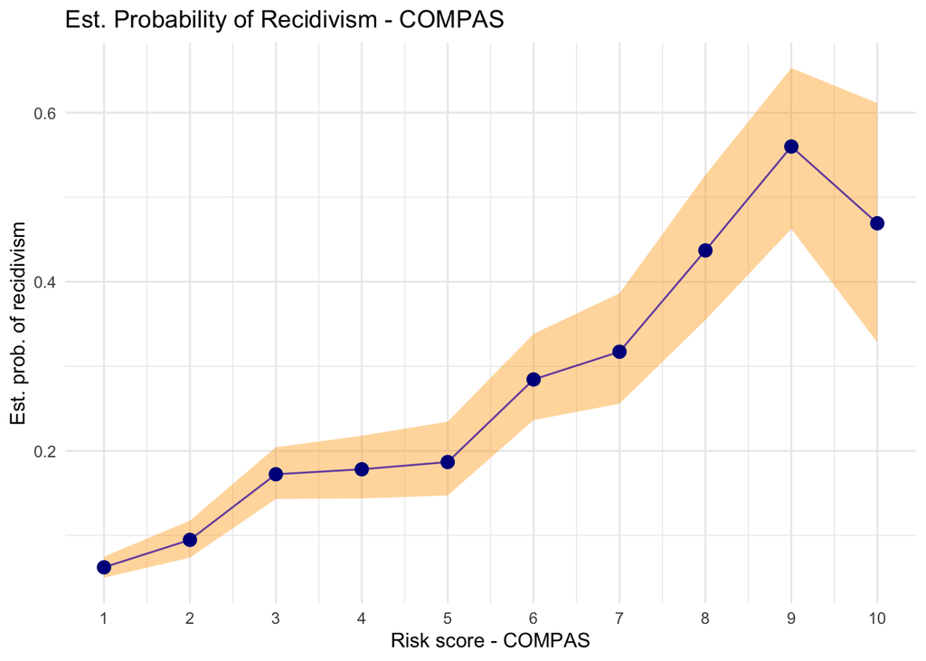

```r
ggplot(b_estimate_results, aes(x = score, y = pos_mean)) +
  geom_line(color = "blue") +
  geom_ribbon(aes(ymin = low_ci, ymax = up_ci), fill = "orange", alpha = 0.4) +
  geom_point(size = 3, color = "darkblue") +
  labs(
    title = "Est. Probability of Recidivism - COMPAS",
    x = "Risk score - COMPAS",
    y = "Est. prob. of recidivism"
  ) +
  theme_minimal() +
  scale_x_continuous(breaks = 1:10)
```

## c. Risk Score and Probability (by race)

Repeat the analysis, but this time do so for every race. Produce a set of plots (one per race) and comment on the patterns.

**Solution**

```r
race_groups <- risk %>%
  group_by(race, score) %>%
  summarize(
    recidivated = sum(outcome == 1),
    cases = n(),
    b_estimate = list(bayesian_estimate(sum(outcome == 1), n()))
  ) %>%
  mutate(
    pos_mean = sapply(b_estimate, function(x) x$sample_mean),
    low_ci = sapply(b_estimate, function(x) x$lower_conf),
    up_ci = sapply(b_estimate, function(x) x$upper_conf)
  ) %>%
  ungroup()  %>%
  filter(!is.na(pos_mean))
race_groups
```

```
# A tibble: 52 × 8
  race             score recidivated cases b_estimate   pos_mean low_ci up_ci
  <chr>            <dbl>       <int> <int> <list>          <dbl>  <dbl> <dbl>
1 African-American     1          31   395 <named list>   0.0812 0.0561 0.108
2 African-American     2          28   294 <named list>   0.0968 0.0659 0.131
3 African-American     3          55   278 <named list>   0.201  0.157  0.248
4 African-American     4          40   233 <named list>   0.176  0.129  0.225
5 African-American     5          42   185 <named list>   0.229  0.172  0.295
6 African-American     6          59   191 <named list>   0.312  0.248  0.381
# ℹ 46 more rows
```

```
$`African-American`
```

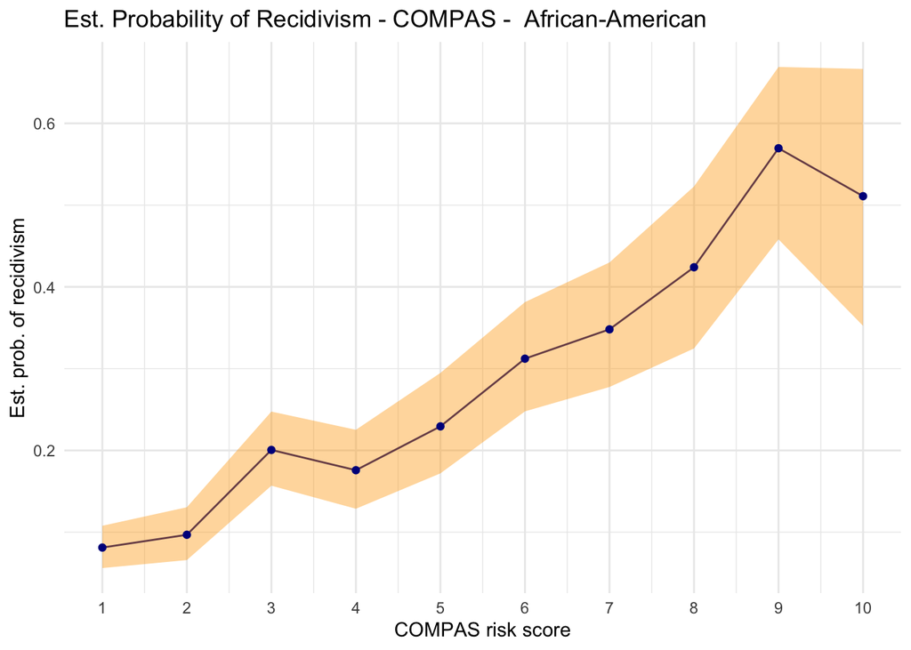

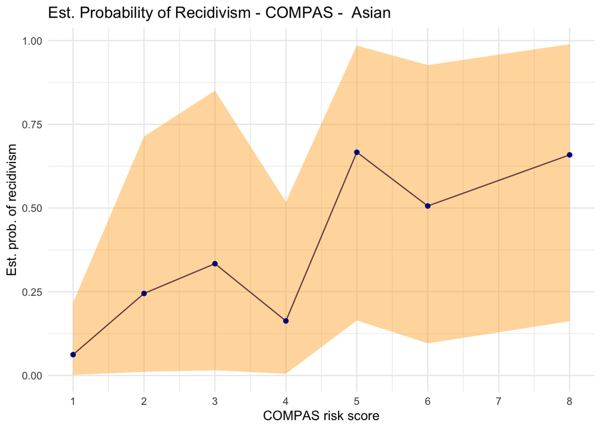

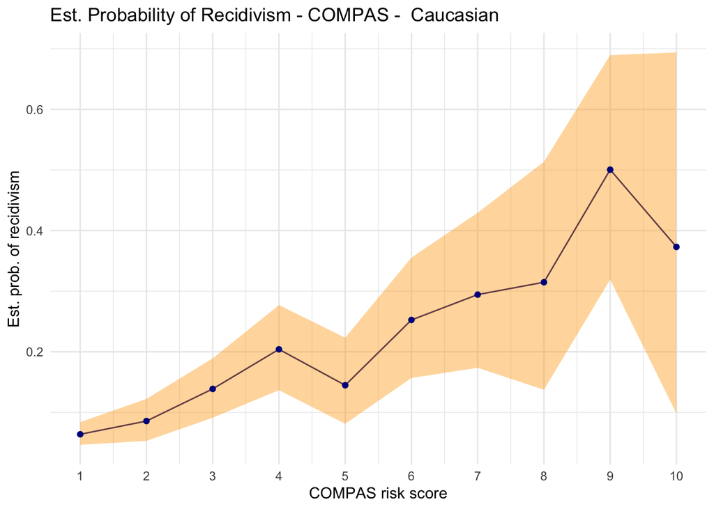

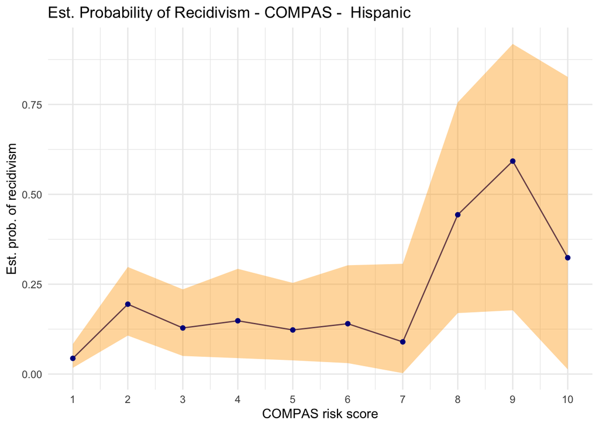

```
$`Native American`
```

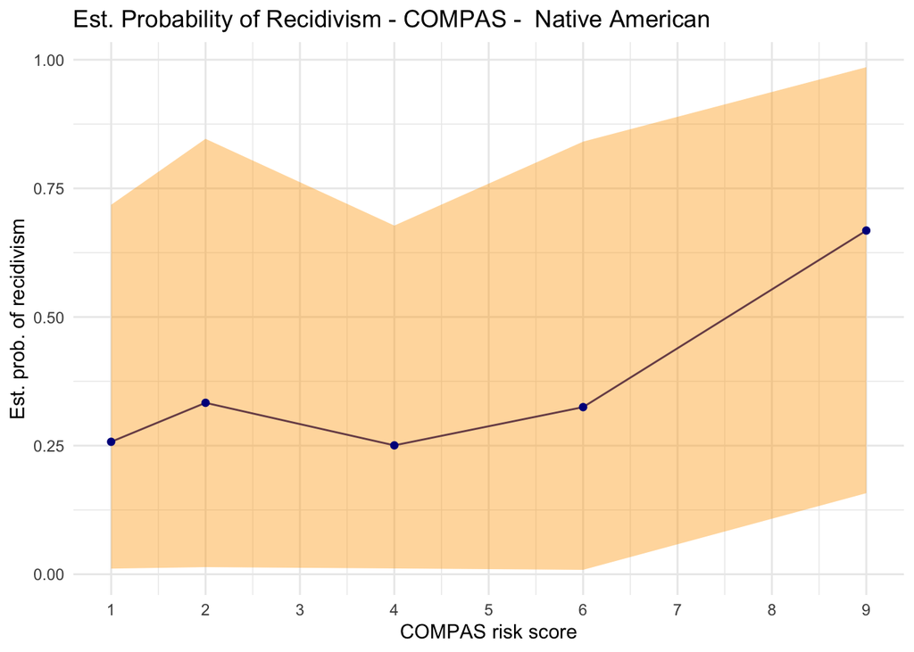

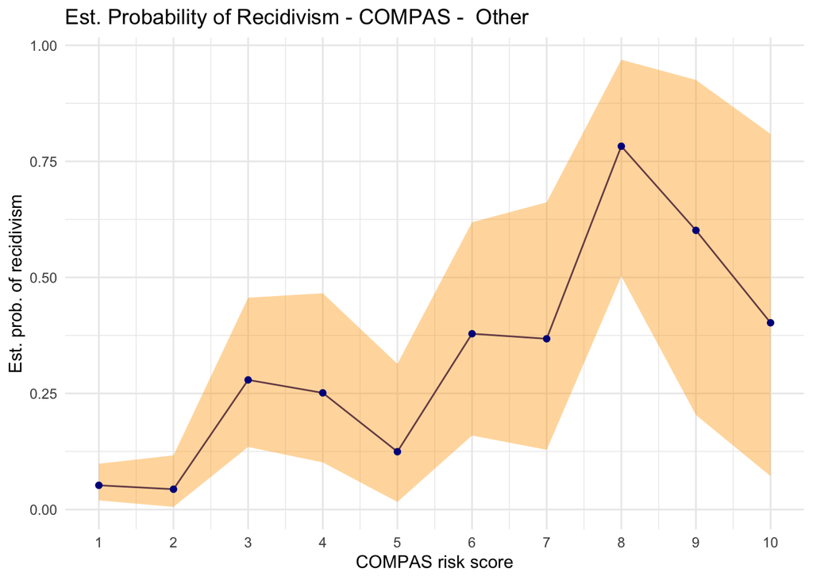

```r
race_plots <- race_groups %>%
  split(.$race) %>%
  lapply(function(risk) {
    ggplot(risk, aes(x = score, y = pos_mean)) +
      geom_line(color = "navy") +
      geom_ribbon(aes(ymin = low_ci, ymax = up_ci), fill = "orange", alpha = 0.4) +
      geom_point(color = "darkblue") +
      labs(
        title = paste("Est. Probability of Recidivism - COMPAS - ", unique(risk$race)),
        x = "COMPAS risk score",
        y = "Est. prob. of recidivism"
      ) +
      theme_minimal() +
      scale_x_continuous(breaks = 1:10)
  })

race_plots
```

## d. ROC Curves

Use the raw COMPAS risk scores to make a ROC curve for each race.

- Are the best discriminating models the ones you expected?
- Are the ROC curves helpful in evaluating the COMPAS risk score?

**Solution**

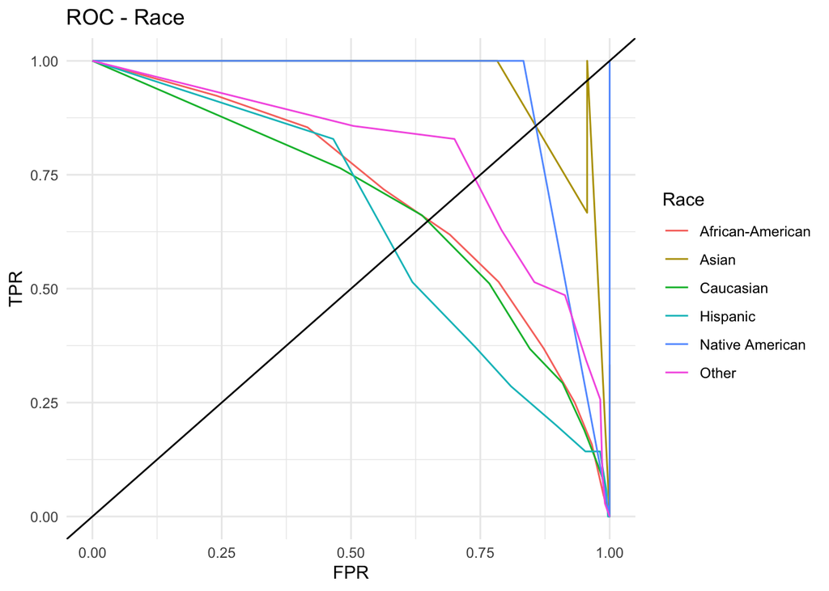

```r
races <- unique(risk$race)

roc_data_list <- list()

for (race in races) {
  race_groups2 <- risk %>% filter(race == !!race)

  y_actual <- race_groups2$outcome
  y_score <- race_groups2$score

  roccurve <- roc(y_actual, y_score)

  roc_data_list[[race]] <- data.frame(
    fpr = rev(roccurve$specificities),  # False positive rate (1 - specificity)
    tpr = rev(roccurve$sensitivities),  # True positive rate (sensitivity)
    race = race,
    auc = rep(auc(roccurve))
  )
}
df_roc <- do.call(rbind, roc_data_list)

ggplot(df_roc, aes(x = fpr, y = tpr, color = race)) +
  geom_line() +
  geom_abline() +
  labs(
    title = "ROC - Race",
    x = "FPR",
    y = "TPR"
  ) +
  scale_color_discrete(name = "Race") +
  theme_minimal()
```